# TidyTuesday 2019-05-28: Wine Rankings

```r
library(tibble, quietly = TRUE)
library(Matrix, quietly = TRUE)
library(dplyr, quietly = TRUE)
library(purrr, quietly = TRUE)
library(irlba, quietly = TRUE)
library(uwot, quietly = TRUE)
library(Rphenograph, quietly = TRUE)
library(colorway)
```

This notebook is an exploration of wine ratings, as described here: https://github.com/rfordatascience/tidytuesday/tree/master/data/2019/2019-05-28

Retrieve data

```r
wine_ratings <- readr::read_csv("https://raw.githubusercontent.com/rfordatascience/tidytuesday/master/data/2019/2019-05-28/winemag-data-130k-v2.csv")
```

130,000 ratings! Let’s check them out:

```r
str(wine_ratings)
```

```
Classes ‘spec_tbl_df’, ‘tbl_df’, ‘tbl’ and 'data.frame':    129971 obs. of  14 variables:
 $ X1                   : num  0 1 2 3 4 5 6 7 8 9 ...
 $ country              : chr  "Italy" "Portugal" "US" "US" ...
 $ description          : chr  "Aromas include tropical fruit, broom, brimstone and dried herb. The palate isn't overly expressive, offering un"| __truncated__ "This is ripe and fruity, a wine that is smooth while still structured. Firm tannins are filled out with juicy r"| __truncated__ "Tart and s…
 $ designation          : chr  "Vulkà Bianco" "Avidagos" NA "Reserve Late Harvest" ...
 $ points               : num  87 87 87 87 87 87 87 87 87 87 ...
 $ price                : num  NA 15 14 13 65 15 16 24 12 27 ...
 $ province             : chr  "Sicily & Sardinia" "Douro" "Oregon" "Michigan" ...
 $ region_1             : chr  "Etna" NA "Willamette Valley" "Lake Michigan Shore" ...
 $ region_2             : chr  NA NA "Willamette Valley" NA ...
 $ taster_name          : chr  "Kerin O’Keefe" "Roger Voss" "Paul Gregutt" "Alexander Peartree" ...
 $ taster_twitter_handle: chr  "@kerinokeefe" "@vossroger" "@paulgwine " NA ...
 $ title                : chr  "Nicosia 2013 Vulkà Bianco  (Etna)" "Quinta dos Avidagos 2011 Avidagos Red (Douro)" "Rainstorm 2013 Pinot Gris (Willamette Valley)" "St. Julian 2013 Reserve Late Harvest Riesling (Lake Michigan Shore)" ...
 $ variety              : chr  "White Blend" "Portuguese Red" "Pinot Gris" "Riesling" ...
 $ winery               : chr  "Nicosia" "Quinta dos Avidagos" "Rainstorm" "St. Julian" ...
 - attr(*, "spec")=
  .. cols(
  ..   X1 = col_double(),
  ..   country = col_character(),
  ..   description = col_character(),
  ..   designation = col_character(),
  ..   points = col_double(),
  ..   price = col_double(),
  ..   province = col_character(),
  ..   region_1 = col_character(),
  ..   region_2 = col_character(),
  ..   taster_name = col_character(),
  ..   taster_twitter_handle = col_character(),
  ..   title = col_character(),
  ..   variety = col_character(),
  ..   winery = col_character()
  .. )
```

How many unique wines are there?

```r
length(unique(wine_ratings$title))
```

```
[1] 118840
```

OK, mostly one rating per wine, then. Are there exceptions?

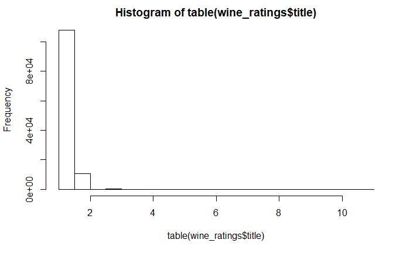

```r
hist(table(wine_ratings$title), breaks = 20)
```

Just a couple with up to 10 ratings.

Since I’m interested in descriptions, let’s see how many have a description, and how long they are per rating:

```r
sum(!is.na(wine_ratings$description))
```

```
[1] 129971
```

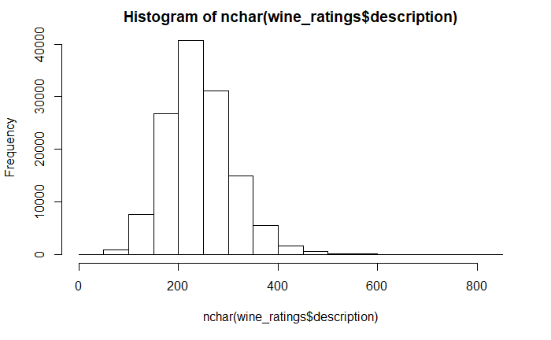

```r
hist(nchar(wine_ratings$description))
```

That looks pretty good! Mostly not missing information, and at least a couple hundred characters per wine to play with.

To start this analysis, I want a set of all of the words in the descriptions.

```r
split_descriptions <- map(wine_ratings$description,
                          function(x) {
                            # Remove separating characters/punctuation
                            # Keep dashes for things like "chunky-feeling"
                            splits <- strsplit(x, "[ ,\\.\t;:()]+")
                            tolower(unlist(splits))
                          })

all_words <- unique(unlist(split_descriptions))

length(all_words)
```

```
[1] 48392
```

~48k different words - that’s a decent set of features.

Let’s build a sparse matrix of the occurrences of these words for each description.

```r
if(!file.exists("binary_matrix.rda")) {
  sparse_i <- map(split_descriptions,
                  function(desc_words) {
                    unique_words <- unique(desc_words)
                    which(all_words %in% unique_words)
                  })

  sparse_p <- c(0, cumsum(map_int(sparse_i, length)))

  binary_matrix <- sparseMatrix(i = unlist(sparse_i),
                                p = sparse_p,
                                x = rep(1, length(unlist(sparse_i))),
                                dims = c(length(all_words),
                                         length(sparse_i)))
  rownames(binary_matrix) <- all_words

  saveRDS(binary_matrix,
        file = "binary_matrix.rda")
} else {
  binary_matrix <- readRDS("binary_matrix.rda")
}
```

To find similarities, let’s use TF-IDF (Term Frequency x Inverse Document Frequency) to find terms that are common enough to compare, and weight the terms for SVD.

This is inspired by analysis of sparse single-cell ATAC-seq data by Cusanovich and Hill, provided here: https://github.com/shendurelab/mouse-atac/blob/master/dim_reduction/dim_reduction.R

First, we’ll remove common and non-descriptive words. Let’s look at the words with > 5,000 occurrences:

```r
t_binary_matrix <- t(binary_matrix)

word_occurrences <- Matrix::colSums(t_binary_matrix)

word_occurrences[word_occurrences > 5e3]
```

```
      aromas        fruit          and        dried         herb          the       palate        apple       citrus    alongside
       39120        40623       127233         7300         6224       104917        37279        11725        10880         5381
     acidity         this           is         ripe       fruity            a         wine         that       smooth        while
       34078        98410        70084        25384         9295       102671        63018        32446         6984        11471
       still   structured         firm      tannins          are          out         with        juicy          red        berry
        5515         5144         8952        29932        23563         7466        85360         9624        16840        14197
      fruits         it's           it         will           be         from         tart      flavors           of         some
       12907        27512        44849         7726         6969        28053         6046        59541        99531         8492
       green      through        crisp          all        lemon       orange          bit         more        notes           to
        8380        10996        12530         6525         7894         5156         5653         9580        17929        45490
      finish         like           as       tannic       herbal         good   blackberry    raspberry           in        mouth
       34687         5703        12496         6163         5501         8963        12073         9030        48401         5766
        full        spicy         dark         plum        fresh          but       bright        opens        white       pepper
        9728         6952        10539        13030        16083        27944        10686         5557        11108         9500
      savory         over     balanced         soft          dry       offers        spice      texture         very          for
        5054         5004         7790        13172        14918        12439        18010        12209         9554        19873
       peach           an          has       flavor          its         pear        touch        drink          now    structure
        8177        17031        23003         5882        16109         7393         8301        29643        14854         7486
    cabernet           by       merlot    chocolate           at      mineral    character         well         rich        black
        8894        19176         5625         8022        10077         5844         8013        10014        16630        21792
      cherry          oak      vanilla         give           on        years        style          not         into      tobacco
       25698        15410        10306         5644        37347         7389         5245         7738         5992         5009
     balance      leather         wood         nose  full-bodied           up        blend    sauvignon      currant        along
        5557         5204         5733        16724         5217         7181        12853         7386         5556         5296
        hint        pinot           or         just     licorice        toast         lead        light        clean        shows
        5876         6255         7050         6057         5911         5522         5176        10757         5523        11267
        made        sweet concentrated         note      there's        syrah         long         fine       creamy        dense
        6479        11749         6299         5975         5524         5071         5736         5716         5520         5285
       there        hints           so    delicious         also          age        aging
        5881         5014         5314         5111         6127         5475         5030
```

There’s a mix here of important descriptive terms and extremely common words that aren’t very informative. setting a hard cutoff may not be the way to go. Instead, I’ll manually curate a blacklist:

```r
word_blacklist <- c("a","it","in","from","wine","for","and","that","an","the","of","has","on",
                    "are","with","now","to","by","this","at","is","as","it's","its",
                    "or","so","also","there's","be","there")

word_occurrences[word_occurrences > 5e3 & !all_words %in% word_blacklist]
```

```
      aromas        fruit        dried         herb       palate        apple       citrus    alongside      acidity         ripe
       39120        40623         7300         6224        37279        11725        10880         5381        34078        25384
      fruity       smooth        while        still   structured         firm      tannins          out        juicy          red
        9295         6984        11471         5515         5144         8952        29932         7466         9624        16840
       berry       fruits         will         tart      flavors         some        green      through        crisp          all
       14197        12907         7726         6046        59541         8492         8380        10996        12530         6525
       lemon       orange          bit         more        notes       finish         like       tannic       herbal         good
        7894         5156         5653         9580        17929        34687         5703         6163         5501         8963
  blackberry    raspberry        mouth         full        spicy         dark         plum        fresh          but       bright
       12073         9030         5766         9728         6952        10539        13030        16083        27944        10686
       opens        white       pepper       savory         over     balanced         soft          dry       offers        spice
        5557        11108         9500         5054         5004         7790        13172        14918        12439        18010
     texture         very        peach       flavor         pear        touch        drink    structure     cabernet       merlot
       12209         9554         8177         5882         7393         8301        29643         7486         8894         5625
   chocolate      mineral    character         well         rich        black       cherry          oak      vanilla         give
        8022         5844         8013        10014        16630        21792        25698        15410        10306         5644
       years        style          not         into      tobacco      balance      leather         wood         nose  full-bodied
        7389         5245         7738         5992         5009         5557         5204         5733        16724         5217
          up        blend    sauvignon      currant        along         hint        pinot         just     licorice        toast
        7181        12853         7386         5556         5296         5876         6255         6057         5911         5522
        lead        light        clean        shows         made        sweet concentrated         note        syrah         long
        5176        10757         5523        11267         6479        11749         6299         5975         5071         5736
        fine       creamy        dense        hints    delicious          age        aging
        5716         5520         5285         5014         5111         5475         5030
```

We also need to trim things that are too rare to be informative for clustering. For now, let’s go with words that appear at least 10 times.

```r
occurrence_threshold <- 10

keep_words <- word_occurrences >= occurrence_threshold & !names(word_occurrences) %in% word_blacklist

sum(keep_words)
```

```
[1] 9783
```

Then, we’ll filter the matrix and perform TF-IDF normalization, which will increase the weight for rare words:

```r
ncounts <- t(t_binary_matrix[,keep_words])

## Normalize the data with TF-IDF
nfreqs <- t(t(ncounts) / Matrix::colSums(ncounts))
tf_idf_counts <- nfreqs * log(1 + ncol(ncounts) / Matrix::rowSums(ncounts))

tf_idf_counts@x <- log1p(tf_idf_counts@x * 1e5)
```

Here’s the SVD step:

```r
set.seed(0)

SVD <- irlba(tf_idf_counts, 50, 50, maxit=1000)
d_diagtsne <- matrix(0, nrow=length(SVD$d), ncol=length(SVD$d))
diag(d_diagtsne) <- SVD$d
vd <- t(d_diagtsne %*% t(SVD$v))
colnames(vd) <- paste0('pca_', 1:ncol(vd))
```

Now we can use UMAP to get a 2d view of the reviews (Rtsne was too slow):

```r
umap_results <- umap(vd,
                     n_neighbors = 10,
                     min_dist = 0.5,
                     verbose = TRUE)
```

Let’s see if there’s any overall structure:

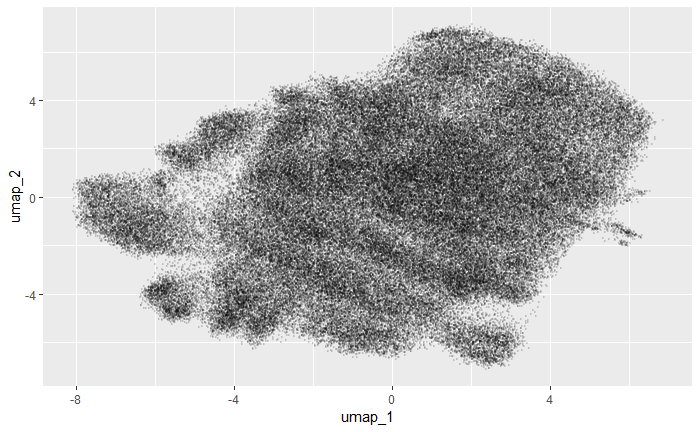

```r
library(ggplot2)

umap_df <- as.data.frame(umap_results)
names(umap_df) <- c("umap_1","umap_2")

ggplot(umap_df) +
  geom_point(aes(x = umap_1,
                 y = umap_2),
             alpha = 0.1,
             size = 0.1)
```

Interesting - not a lot of distinct islands. Looks pretty continuous. Let’s take a look at a couple of terms that I would think are pretty common - “red” and “white” - and see how they’re distributed.

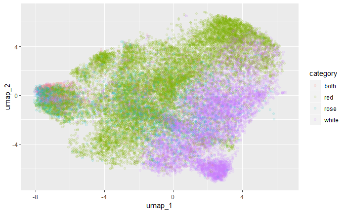

```r
plot_df <- umap_df
plot_df$red <- t_binary_matrix[,"red"]
plot_df$white <- t_binary_matrix[,"white"]
plot_df$rose <- t_binary_matrix[,"rose"]
plot_df$category <- "neither"
plot_df$category[plot_df$red == 1 & plot_df$white == 0] <- "red"
plot_df$category[plot_df$red == 0 & plot_df$white == 1] <- "white"
plot_df$category[plot_df$red == 1 & plot_df$white == 1] <- "both"
plot_df$category[plot_df$rose == 1] <- "rose"

bg <- plot_df[plot_df$category == "neither",]
fg <- plot_df[plot_df$category != "neither",]

ggplot() +
  geom_point(data = fg,
             aes(x = umap_1,
                 y = umap_2,
             color = category),
             alpha = 0.1)
```

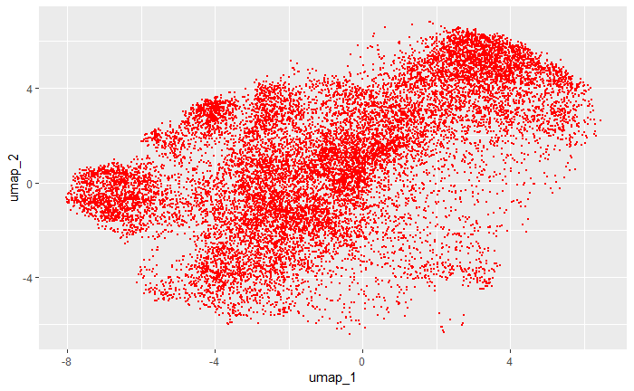

```r
ggplot() +
  geom_point(data = fg[fg$category == "red",],
             aes(x = umap_1,
                 y = umap_2),
             color = "red",
             size = 0.1) +
  scale_color_identity()
```

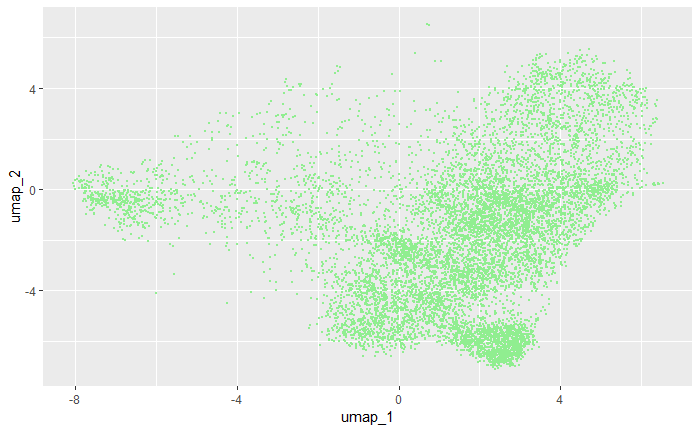

```r
ggplot() +
  geom_point(data = fg[fg$category == "white",],
             aes(x = umap_1,
                 y = umap_2),
             color = "lightgreen",
             size = 0.1) +
  scale_color_identity()
```

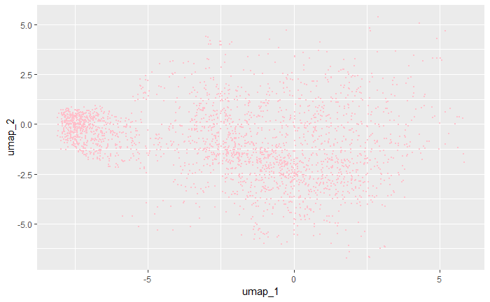

```r
ggplot() +
  geom_point(data = fg[fg$category == "rose",],
             aes(x = umap_1,
                 y = umap_2),
             color = "pink",
             size = 0.1) +
  scale_color_identity()
```

Interesting. Looks like there’s some separation of reviews based on these terms. The group on the left seems to be a mix of red, white, and rose.

```r
wine_ratings <- cbind(wine_ratings, umap_df)
```

Do ratings group?

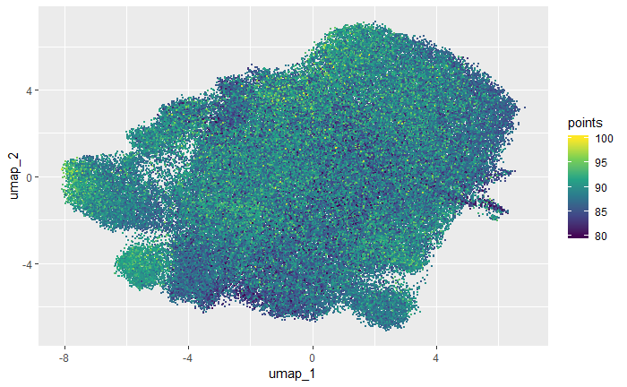

```r
ggplot() +
  geom_point(data = wine_ratings,
             aes(x = umap_1,
                 y = umap_2,
                 color = points),
             size = 0.1) +
  scale_color_viridis_c()
```

No - that’s interesting!

How about prices?

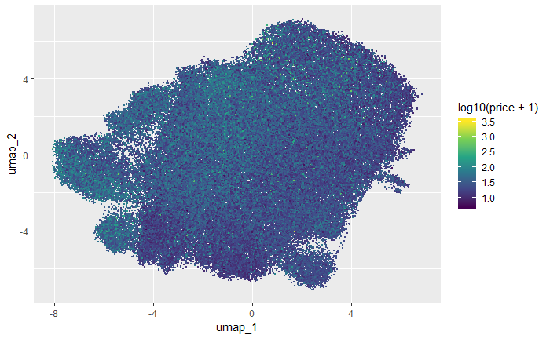

```r
ggplot() +
  geom_point(data = wine_ratings[!is.na(wine_ratings$price),],
             aes(x = umap_1,
                 y = umap_2,
                 color = log10(price + 1)),
             size = 0.1) +
  scale_color_viridis_c()
```

Also doesn’t look too strong. How about variety? That should group based on terms:

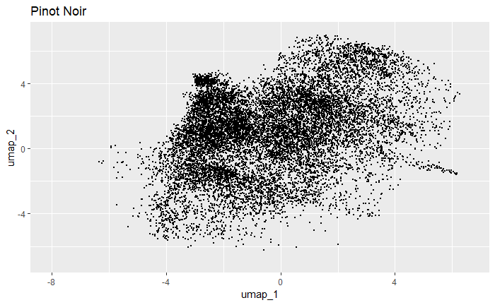

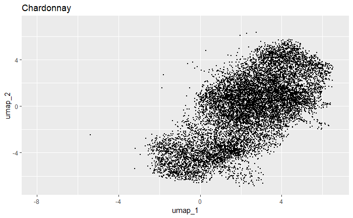

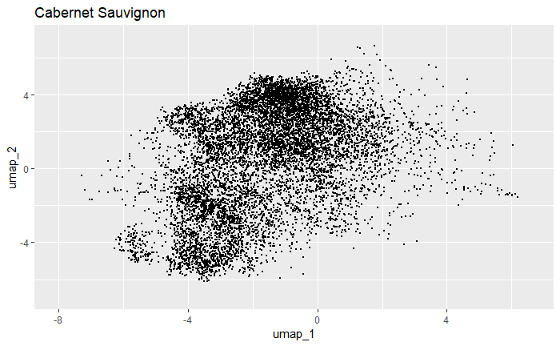

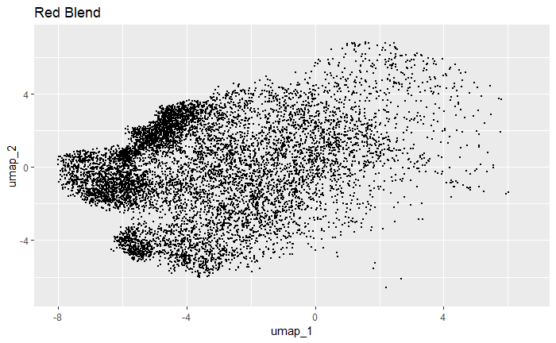

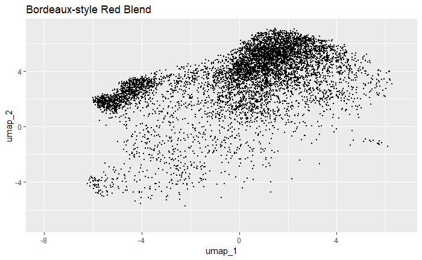

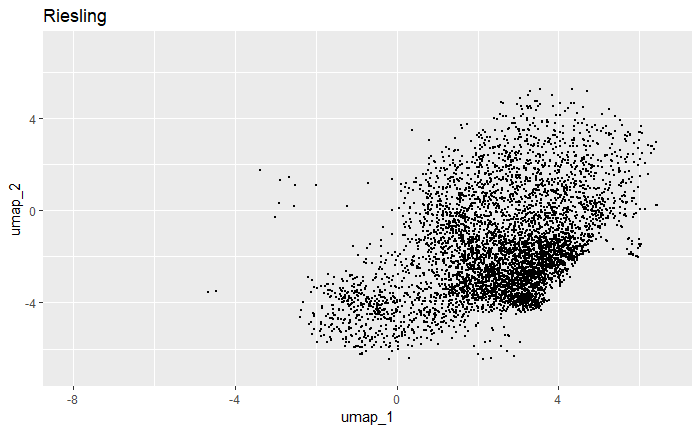

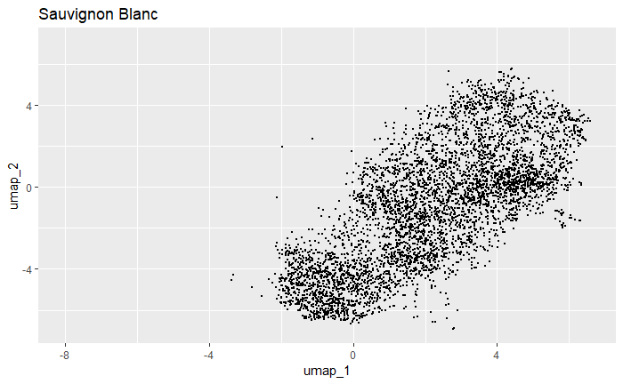

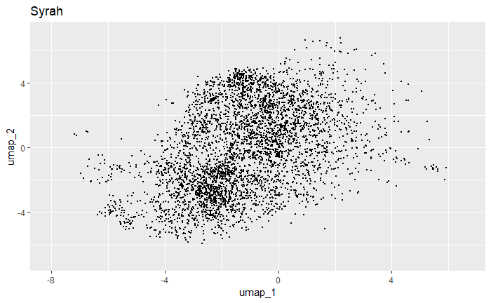

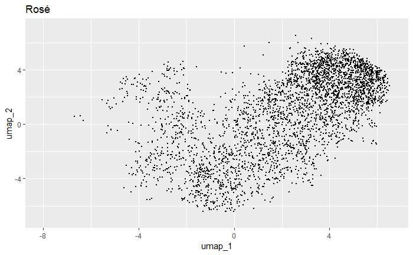

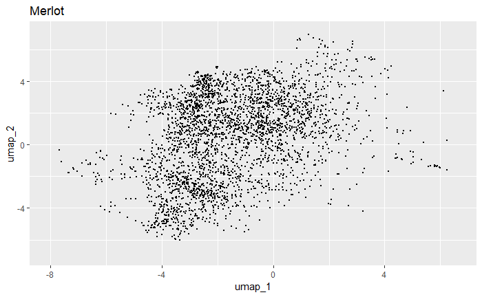

```r
variety_freq <- table(wine_ratings$variety)
variety_freq <- variety_freq[order(variety_freq, decreasing = TRUE)]
top_varieties <- wine_ratings[wine_ratings$variety %in% names(variety_freq[1:10]),]

map(names(variety_freq)[1:10],
    function(x) {
      variety_df <- top_varieties[top_varieties$variety == x,]
      ggplot() +
        geom_point(data = variety_df,
                   aes(x = umap_1,
                       y = umap_2),
                   size = 0.1) +
        scale_x_continuous(limits = range(top_varieties$umap_1)) +
        scale_y_continuous(limits = range(top_varieties$umap_2)) +
        ggtitle(x)
    })
```

Looks like a couple of these separate well, but others are pretty spread out.

Let’s try clustering the descriptions using Rphenograph:

```r
pg_results <- Rphenograph(umap_results,
                          k = 30)
```

```
Run Rphenograph starts:
  -Input data of 129971 rows and 2 columns
  -k is set to 30
```

```
  Finding nearest neighbors...DONE ~ 1.56 s
  Compute jaccard coefficient between nearest-neighbor sets...DONE ~ 44.3 s
  Build undirected graph from the weighted links...DONE ~ 20.58 s
  Run louvain clustering on the graph ...DONE ~ 10.41 s
```

```
Run Rphenograph DONE, totally takes 76.85s.
```

```
  Return a community class
  -Modularity value: 0.9574679
  -Number of clusters: 74
```

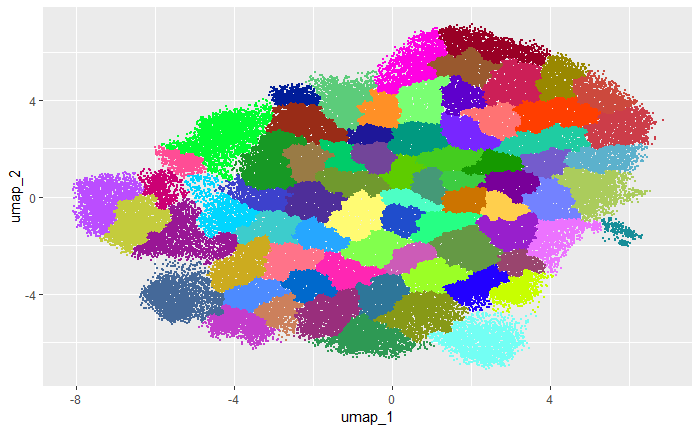

```r
pg_clusters <- as.character(membership(pg_results[[2]]))
pg_colors <- varibow(length(unique(pg_clusters)))

ggplot() +
  geom_point(data = wine_ratings,
             aes(x = umap_1,
                 y = umap_2,
                 color = pg_clusters),
             size = 0.1) +
  scale_color_manual(breaks = unique(pg_clusters),
                     values = pg_colors) +
  theme(legend.position = "none")
```